# Generalized Additive Models & Time Series

## Overview of today’s material

- **What are Generalized Additive Models (GAMs)?**
- **Smooth Functions, Splines, Basis Functions, and Knots**
- **Key Differences and Similarities with Dynamic Linear Models (DLMs)**
- **GAMs in Time Series Analysis**
- **Applications of GAMs**

## What is a Generalized Additive Model (GAM)?

- **GAMs** are a class of statistical models used to model complex, non-linear relationships between the response and the predictors.
- **Key idea**: GAMs model the mean of the response variable as a sum of smooth functions of the predictors.

## GAM Formula

- The expected value of the response variable is modeled as:

  \[ E[Y] = \beta_0 + f_1(x_1) + f_2(x_2) + \dots + f_k(x_k) \]
- Where:
  - \(E[Y]\) is the expected value (mean) of the response variable \(Y\).
  - \(\beta_0\) is the intercept.
  - \(f_1(x_1), f_2(x_2), \dots\) are smooth functions of the predictors \(x_1, x_2, \dots\).

## Smooth Functions in GAMs

- A smooth function allows us to model **non-linear relationships** in the data without needing to specify a fixed functional form
- Smoothness is controlled by a penalty term, helping to avoid overfitting.
- Common types of smooth functions used in GAMs:
  - **Splines** (B-splines, cubic splines, thin-plate splines)
  - **Kernel smoothing**
  - **Local regression (LOESS)**
  - **Gaussian processes**

## Smooth Functions vs. Linear Models

- **Linear Models**: Assume a linear relationship between predictors and the response \[ E[Y] = \beta_0 + \beta_1 x_1 + \beta_2 x_2 + \dots + \beta_k x_k \]
- **GAMs**: Allow for flexible, non-linear relationships by fitting smooth functions: \[ E[Y] = \beta_0 + f_1(x_1) + f_2(x_2) + \dots + f_k(x_k) \]
- **Key Advantage**: GAMs are more flexible in capturing complex trends in data that cannot be adequately modeled with a simple linear relationship (and have flexible families)

## Smooth Functions in `mgcv`

Very powerful R package for fitting GAMs

Univariate smooth terms are expressed as

```r
gam(y ~ s(x1, k = 10, bs = "cr") +
      s(x2, k = 10, bs = "cr"), data = data)
```

We’ll cover more complicated smooths later

## Splines and Their Role in GAMs

- **Splines**: Mathematical functions that are piecewise polynomial and used to fit smooth curves to data
- **Why Splines?**:
  - Allow for flexible, smooth curves that can adapt to data patterns
  - Avoid overfitting by controlling the complexity of the curve
- **Some Types of Splines**:
  - **B-splines (Basis Splines)**: Commonly used due to computational efficiency and flexibility
  - **Cubic Splines**: Splines with cubic polynomials between each pair of adjacent knots
  - **Thin-plate Splines**: A generalization of B-splines, used for higher-dimensional data

## What Are Knots in Splines?

- **Knots**: Points where the pieces of the spline curve join
- **Importance**: Knots define the structure of the spline – more knots allows for more wiggliness
- **Placement**: Knots can be placed:
  - **Evenly**: Common approach, but not always optimal
  - **Data-driven placement**: Placed where data points are dense or where significant changes in the response occur

## Visualizing B-Splines and Their Role in GAMs

To better understand how B-splines work, let’s visualize basis functions and see how they combine to form a smooth function

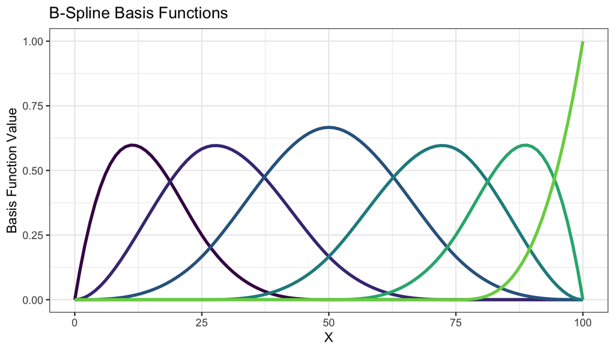

## Basis Functions and B-Splines

- **Basis Functions**: Functions that form the building blocks of splines (used to construct the overall smooth function)
- **B-splines** are defined using a set of basis functions, each associated with a knot. The smooth curve is formed by a weighted sum of these basis functions.
- **B-spline Basis**: The basis functions for B-splines have the following properties:
  - They are piecewise-defined polynomials
  - They are non-negative and have local support (i.e., each basis function is non-zero only in a limited range)

## How Basis Functions Build Splines

- **Weighted Sum of Basis Functions**: The final spline is created by summing these basis functions, each weighted by a coefficient. This allows the spline to adapt to the data and capture non-linear relationships.

  \[ f(x) = \sum_{i=1}^{n} w_i \cdot B_i(x) \]
  - \(f(x)\) is the smooth function (spline) estimated by the GAM.
  - \(B_i(x)\) are the individual basis functions.
  - \(w_i\) are the coefficients (weights) that scale each basis function to fit the data.

## How Basis Functions Build Splines

`weights <- c(0.4, -0.5, 0.3, 0.1, 0.6, -0.2)`

[figure not shown]

## Adjusting in `mgcv`

```r
gam(y ~ s(x1, k = 10, bs = "cr") +
      s(x2, k = 10, bs = "cr"), data = data)
```

## Key Take Homes

- **It doesn’t take many basis functions to create a flexible spline**
- **Flexibility is controlled by**:
  - The number of knots and how they are placed
  - The number of basis functions used in the spline construction
    - More basis functions (higher df) -> more flexibility
  - We used 6 basis functions (df) in the last example
- **Important Considerations**:
  - Too few basis functions may lead to underfitting (not capturing the complexity of the data)
  - Too many basis functions (too high df) -> overfitting, as spline becomes too wiggly
- **Knots and Basis Functions**:
  - Knots define where the individual pieces of the spline connect
  - The placement of knots (evenly spaced vs. data-driven) can significantly impact the flexibility and accuracy of the model

## What are Knots in Splines?

- **Knots**: Points where the individual segments of the spline curve meet
- **Function of Knots**:
  - The placement of knots determines flexibility
- **More Knots**:
  - Allow for more flexibility, creating more complex curves
  - Increase the risk of overfitting
- **Fewer Knots**:
  - Lead to smoother curves, but may underfit the data
  - Lack the ability to capture complex non-linear patterns
- **Summary**: The number and position of knots affect how well the spline can match patterns in the data

## Example: Effect of Knot Placement on Spline Fit

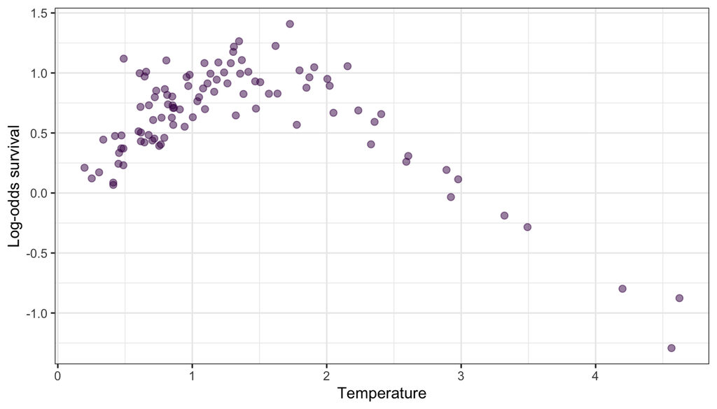

## `mgcv` default is to distribute them based on data

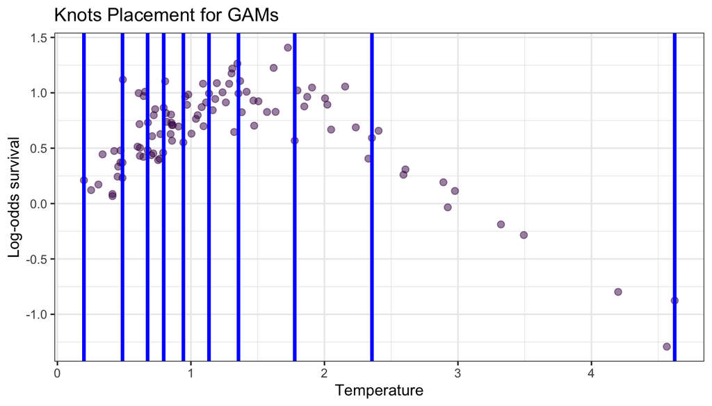

## `mgcv` default is to distribute them based on data

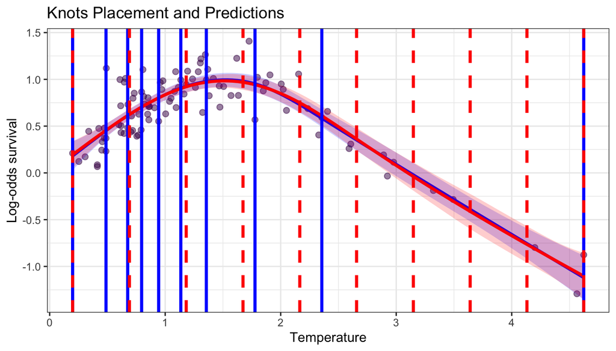